# Introducción a Data Minning Trabajo Final

Pedro Beltramino

MEDGC Rosario | Cohorte 2020-2021 TRABAJO FINAL

Introduccion El incremento de la expectativa de vida ha generado un aumento en la incidencia de enfermedades cardiovasculares y neurológicas. En los adultos mayores es donde se conjugan diversas patologías con alta morbi-mortalidad requiriendo gran cantidad de recursos materiales y humanos. Dado que, la determinación en análisis sanguíneos de rutina permite la detección de alteraciones que en determinadas circunstancias podrían progresar a patologías definidas con serias repercusiones cardiovasculares en este grupo poblacional, se estudió la frecuencia en adultos mayores de diversas patologías subclínicas y la asociación entre los factores de riesgo cardiovascular y dichas patologías subclínicas.

Desde la materia Introducción a la Mnería de Datos se solicita: a. Describir la distribución univariada de las variables presente en el conjunto de datos. ¿Se evidencian outliers en alguna de ellas? b. Calcular e interpretar la matriz de correlaciones. c. Realizar un análisis de componentes principales. ¿Qué porcentaje de la variabilidad total logran explicar las dos primeras componentes? ¿Es posible realizar una interpretación sobre los componentes? ¿Cuál? ¿Logran esas componentes diferenciar a los pacientes según el sexo? d. ¿Existen distintos subgrupos de pacientes en los datos? ¿Cuántos logra identificar? ¿Qué características tienen? Explique la metodología utilizada. e. Construir la variable dicotómica ‘obesidad’ (índice de masa corporal mayor a 30) y construya un modelo predictivo utilizando sólo el sexo del paciente y las variables de los resultados de las pruebas de laboratorio (hematocrito, glicemia, colesterol Total, colesterol HDL y triglicéridos). ¿Qué capacidad predictiva tiene ese modelo?

Se provee el archivo ‘cardio.xls’

El conjunto de datos posee 68 observaciones (personas de ambos sexos mayores de 60 años) de 9 variables definidas de la siguiente manera: sexo: Sexo del paciente (0: Femenino, 1: Masculino). imc: Índice de masa corporal (es el cociente del peso en kg y la estatura al cuadrado en metros). perimetro_abdo: Perímetro abdominal (en centímetros). hto: Hematocrito (porcentaje del volumen de eritrocitos en el volumen de sangre). glicemia: Glicemia (en mg/dL). ct: Colesterol Total (en mg/dL). hdl: Colesterol HDL (en mg/dL). tgd: Triglicéridos (en mg/dL).

Seteos Preliminares - Carga de libreriás y archivos

```r
rm(list = ls())


paquetes <-
  c( "libcoin", "mvtnorm", "care", "readr", "readxl", "dplyr", "tibble", "ggplot2",  "cowplot", "tidyr", "ggridges","ggrepel","ggbeeswarm", "GGally", "plotly", "treemapify", "car",
    "vcd", "colorspace", "tidyverse", "psych", "lubridate","readr","magrittr","gganimate",
   "knitr","PerformanceAnalytics","corrplot","factoextra", "randomForest", "caret", "rpart","rpart.plot", "partykit","lattice", "stats", "psych", "caTools", "performance", "prediction" )



# Instalar si no estan
instalados <- paquetes %in% rownames(installed.packages())
if (any(instalados == FALSE)) {
  install.packages(paquetes[!instalados])
}

# Cargarlos
invisible(lapply(paquetes, library, character.only = TRUE))

cbbPalette <- c("#999999", "#E69F00", "#56B4E9", "#009E73",
                "#F0E442", "#0072B2", "#D55E00", "#CC79A7")

###Carga y Limpieza de Datos
##Carga de Datos: se define directorio donde está guardado el archivo

#setwd(choose.dir())
cardio <- read_xls("cardio.xls")

##Limpieza de Datos
#Vemos la estructura del Set de Datos

str(cardio)
```

```
## tibble [68 x 9] (S3: tbl_df/tbl/data.frame)
##  $ id            : num [1:68] 1 2 3 4 5 6 7 8 9 10 ...
##  $ sexo          : num [1:68] 0 1 0 0 1 0 0 0 0 1 ...
##  $ imc           : num [1:68] 27.8 29.6 24.1 31.3 25 ...
##  $ perimetro_abdo: num [1:68] 84 104.5 91.5 95 90 ...
##  $ hto           : num [1:68] 35 43.5 39.1 42.8 41.1 40.6 38.5 41.6 43.9 35.4 ...
##  $ glicemia      : num [1:68] 1.18 0.93 0.87 0.73 0.98 0.99 1.33 0.83 0.96 1.15 ...
##  $ ct            : num [1:68] 225 293 197 282 154 222 230 195 220 193 ...
##  $ hdl           : num [1:68] 75 37 54 57 24 58 60 60 57 54 ...
##  $ tgd           : num [1:68] 2.1 5.21 1.3 1.18 1.26 1.09 0.99 1.15 1.44 0.92 ...
```

```r
# La variable sexo está como numerica, hay que transformarla en factor.
# De acuerdo a la consigna se reemplazan los valores "0" y "1"
# por "Mujer" y "Hombre". También se transforma en factor la columna ID.

cardio <- mutate(cardio,sexo = factor(cardio$sexo, levels = c(0,1),
                                      labels = c("Mujer", "Hombre")),
                 id=factor(id))

# Detección de datos faltantes:


colSums(is.na(cardio))
```

```
##             id           sexo            imc perimetro_abdo            hto
##              0              0              0              0              0
##       glicemia             ct            hdl            tgd
##              0              0              0              0
```

```r
colSums(cardio == "")
```

```
##             id           sexo            imc perimetro_abdo            hto
##              0              0              0              0              0
##       glicemia             ct            hdl            tgd
##              0              0              0              0
```

```r
## No existen datos faltantes ni vacios en el data frame


#Imprimo los primeros registros luego de las modificaciones


knitr::kable(head(cardio), caption = "Tabla 1. Encabezado de Datos", align = c("c", "c", "c", "c", "c", "c", "c", "c", "c"))
```

Tabla 1. Encabezado de Datos

| id | sexo | imc | perimetro_abdo | hto | glicemia | ct | hdl | tgd |
| --- | --- | --- | --- | --- | --- | --- | --- | --- |
| 1 | Mujer | 27.84599 | 84.0 | 35.0 | 1.18 | 225 | 75 | 2.10 |
| 2 | Hombre | 29.58920 | 104.5 | 43.5 | 0.93 | 293 | 37 | 5.21 |
| 3 | Mujer | 24.13138 | 91.5 | 39.1 | 0.87 | 197 | 54 | 1.30 |
| 4 | Mujer | 31.29737 | 95.0 | 42.8 | 0.73 | 282 | 57 | 1.18 |
| 5 | Hombre | 25.03144 | 90.0 | 41.1 | 0.98 | 154 | 24 | 1.26 |
| 6 | Mujer | 31.40496 | 106.0 | 40.6 | 0.99 | 222 | 58 | 1.09 |

```r
# Y vuelvo a imprimir la estructura
str(cardio)
```

```
## tibble [68 x 9] (S3: tbl_df/tbl/data.frame)
##  $ id            : Factor w/ 68 levels "1","2","3","4",..: 1 2 3 4 5 6 7 8 9 10 ...
##  $ sexo          : Factor w/ 2 levels "Mujer","Hombre": 1 2 1 1 2 1 1 1 1 2 ...
##  $ imc           : num [1:68] 27.8 29.6 24.1 31.3 25 ...
##  $ perimetro_abdo: num [1:68] 84 104.5 91.5 95 90 ...
##  $ hto           : num [1:68] 35 43.5 39.1 42.8 41.1 40.6 38.5 41.6 43.9 35.4 ...
##  $ glicemia      : num [1:68] 1.18 0.93 0.87 0.73 0.98 0.99 1.33 0.83 0.96 1.15 ...
##  $ ct            : num [1:68] 225 293 197 282 154 222 230 195 220 193 ...
##  $ hdl           : num [1:68] 75 37 54 57 24 58 60 60 57 54 ...
##  $ tgd           : num [1:68] 2.1 5.21 1.3 1.18 1.26 1.09 0.99 1.15 1.44 0.92 ...
```

```r
##Resumen Global - Se imprime un Summary quitando la primer columna ID

summary(cardio[,-1])
```

```
##      sexo         imc        perimetro_abdo        hto           glicemia
##  Mujer :35   Min.   :21.91   Min.   : 75.00   Min.   :28.20   Min.   :0.6800
##  Hombre:33   1st Qu.:25.78   1st Qu.: 89.75   1st Qu.:38.88   1st Qu.:0.8775
##              Median :28.16   Median : 99.00   Median :41.40   Median :0.9600
##              Mean   :29.27   Mean   :100.40   Mean   :41.96   Mean   :0.9937
##              3rd Qu.:31.25   3rd Qu.:106.50   3rd Qu.:44.52   3rd Qu.:1.0625
##              Max.   :45.54   Max.   :139.00   Max.   :52.20   Max.   :1.6500
##        ct             hdl             tgd
##  Min.   :143.0   Min.   :24.00   Min.   :0.540
##  1st Qu.:185.5   1st Qu.:46.75   1st Qu.:1.010
##  Median :207.5   Median :57.50   Median :1.150
##  Mean   :212.9   Mean   :57.12   Mean   :1.356
##  3rd Qu.:234.8   3rd Qu.:65.00   3rd Qu.:1.460
##  Max.   :296.0   Max.   :93.00   Max.   :5.210
```

Análisis Descriptivo a- Análisis Univariado###

Observaciones preliminares de las variables en estudio Como primer punto, se observa que las proporciones entre Sexos Femenino y Masculino, están balanceadas. De las variables, el IMC parecería tener los cuartiles cercanos a la media/mediana, pero una cola mucho más larga hacia la derecha, con lo que posiblemente tenga outliers. El hto parecería tener una distribución bastante simétrica, con la media y la mediana muy cercana, similar diferencia de las medidas de tendencia central alos cuartiles y también a los mínimos y a los máximos. En la glicemia, los cuartiles están a distancia similiar de la mediana, pero el máximo a una distancia mucho mayor. Dado que ademas la mediana y la media están “cerca” posiblemente sea un valor atípico más que una cola en la distribución. Algo similar parecería pasar con el Colesterol Total. El HDL parecería ser bastante simétrica, y el TGD parecería tener una cola larga hacia la derecha

Procedemos al análisis univariado en detalle

```r
tapply(cardio$imc,cardio$sexo, mean)
```

```
##    Mujer   Hombre
## 29.23223 29.31843
```

```r
mediasexo <- cardio %>% group_by(sexo) %>% summarise(mean(imc), mean(perimetro_abdo),
                                        mean(hto),mean(glicemia),mean(ct),
                                        mean(hdl),mean(tgd))%>%
  kable()


medianasexo <- cardio %>% group_by(sexo) %>% summarise(median(imc),median(perimetro_abdo),
                                        median(hto),median(glicemia),median(ct),
                                        median(hdl),median(tgd))%>%
  kable()

desviosexo <- cardio %>% group_by(sexo) %>% summarise(sd(imc),sd(perimetro_abdo),
                                        sd(hto),sd(glicemia),sd(ct),
                                        sd(hdl),sd(tgd))%>%
  kable()

mediasexo
```

| sexo | mean(imc) | mean(perimetro_abdo) | mean(hto) | mean(glicemia) | mean(ct) | mean(hdl) | mean(tgd) |
| --- | --- | --- | --- | --- | --- | --- | --- |
| Mujer | 29.23223 | 97.52857 | 40.18571 | 0.9825714 | 217.3714 | 62.82857 | 1.250571 |
| Hombre | 29.31843 | 103.43939 | 43.85152 | 1.0054545 | 208.2424 | 51.06061 | 1.468788 |

```r
medianasexo
```

| sexo | median(imc) | median(perimetro_abdo) | median(hto) | median(glicemia) | median(ct) | median(hdl) | median(tgd) |
| --- | --- | --- | --- | --- | --- | --- | --- |
| Mujer | 27.73186 | 94 | 40.6 | 0.95 | 220 | 62 | 1.11 |
| Hombre | 29.31129 | 102 | 43.7 | 0.96 | 202 | 49 | 1.18 |

```r
desviosexo
```

| sexo | sd(imc) | sd(perimetro_abdo) | sd(hto) | sd(glicemia) | sd(ct) | sd(hdl) | sd(tgd) |
| --- | --- | --- | --- | --- | --- | --- | --- |
| Mujer | 5.261500 | 12.73251 | 3.979812 | 0.1703689 | 40.81600 | 12.34191 | 0.5019195 |
| Hombre | 4.906597 | 14.55311 | 4.653904 | 0.1903302 | 33.90523 | 15.01653 | 0.8407503 |

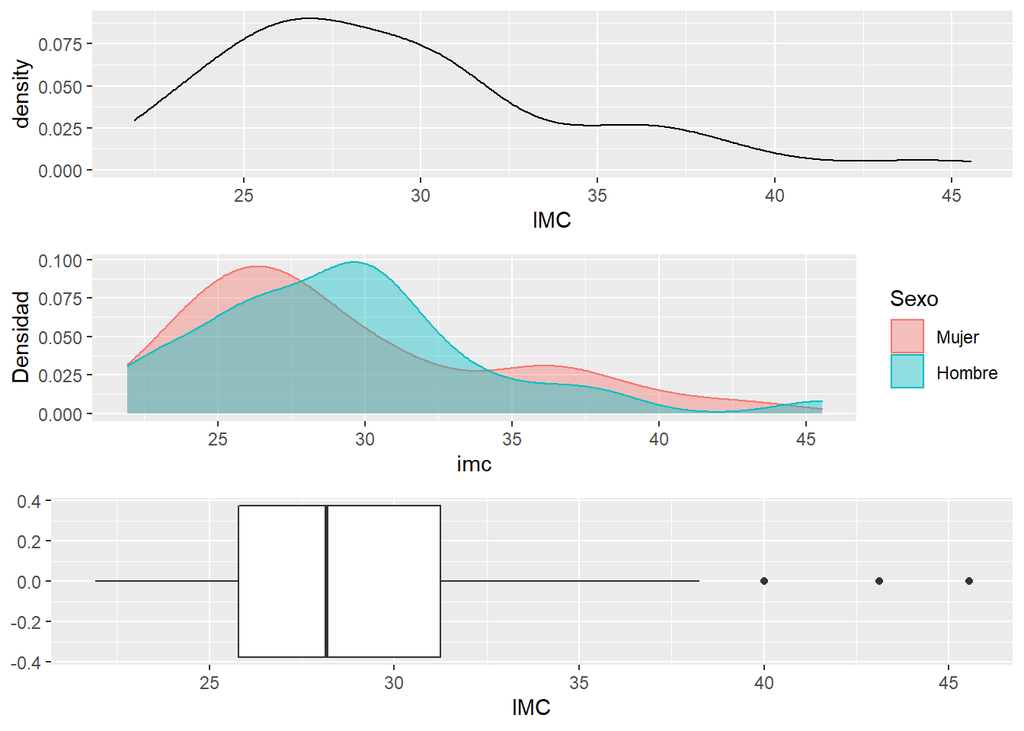

```r
#A primera vista pareciera haber diferencias en el comportamiento
#de las variables dependiendo del sexo.

##2- IMC


g1<-ggplot(cardio) +
  aes(x = imc) +
  geom_density() +
  theme(legend.position = "none") +
  labs(x = "IMC")
g2 <- ggplot(cardio) +
  aes(x = imc, color = sexo, fill = sexo) +
  geom_density(alpha = 0.4) +
  labs(x = "imc", y = "Densidad",
       color = "Sexo",
       fill = "Sexo")
g3 <- ggplot(cardio) +
  aes(x = imc) +
  geom_boxplot() +
  theme(legend.position = "none") +
  labs(x = "IMC")


plot_grid(g1, g2, g3, nrow = 3)
```

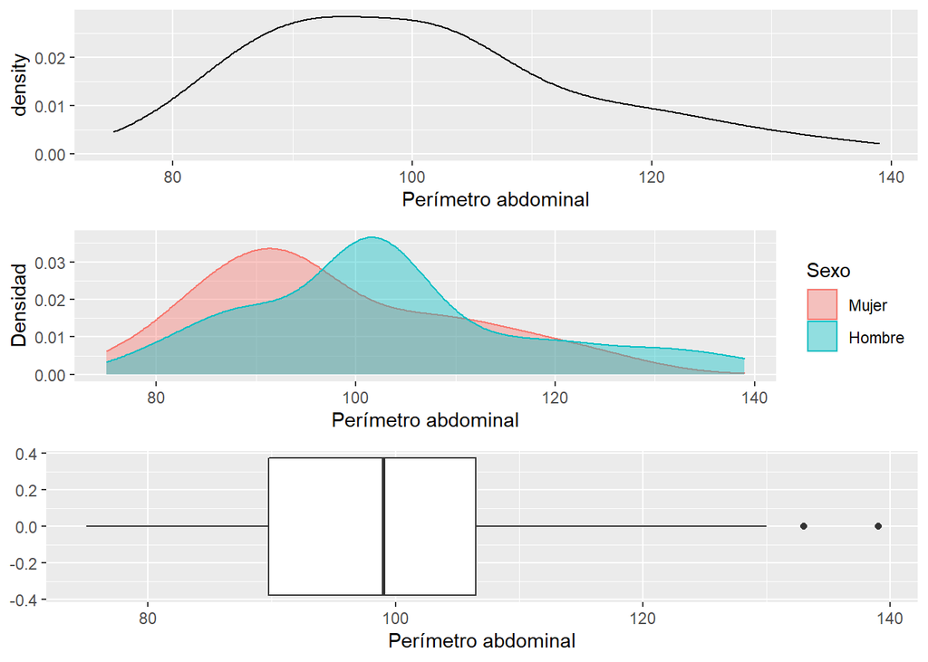

```r
## Para la variable IMC se observan tres outliers en la cola derecha. En linea con el
## analisis preliminar, vemos una cola larga hacia la derecha con valors atioícos
## en esa dirección. Por otro lado, si dividimos las distribuciones por sexo,
## vemos que tienen colas similares, pero que en los hombres las medidas de tendencia
## central tienen un valor mayor



##3- Perimetro Abdominal
g1<-ggplot(cardio) +
  aes(x = perimetro_abdo) +
  geom_density() +
  theme(legend.position = "none") +
  labs(x = "Perímetro abdominal")
g2 <- ggplot(cardio) +
  aes(x = perimetro_abdo, color = sexo, fill = sexo) +
  geom_density(alpha = 0.4) +
  labs(x = "Perímetro abdominal", y = "Densidad",
       color = "Sexo",
       fill = "Sexo")
g3 <- ggplot(cardio) +
  aes(x = perimetro_abdo) +
  geom_boxplot() +
  theme(legend.position = "none") +
  labs(x = "Perímetro abdominal")


plot_grid(g1, g2, g3, nrow = 3)
```